# visualizing distributions lab

Evangeline Reynolds

2/2/2020

For this assignment, consult the [ggplot2 Cheat Sheet](https://rstudio.com/wp-content/uploads/2015/03/ggplot2-cheatsheet.pdf) from RStudio and [geoms: a closer look](https://evamaerey.github.io/ggplot2_grammar_guide/geoms.html#1).

On the ggplot2 Cheat Sheet, there are panels that talk about relevant to “univariate” description (uni = one) and “bivariate” description (bi = two). What exactly are the titles of these panels on the cheat sheet?

> your answer

Within these panels, what are some of the subcategories?

```r
gapminder$long_life <- gapminder$lifeExp >= 70
gapminder$life_cat <- ifelse(gapminder$long_life, "70+", "<70")
gapminder_2007 <- gapminder[gapminder$year == 2007,]
```

# Plotting

With the `gapminder_2007` object you’ve created, create the following visualizations and state the type of variable is each variable is (either **continuous** or **discrete**?)

## Visualizing bivariate (2 variables joint) distributions

### 1. visualize the relationship between gdp per capita and population

> variable types (**continuous** or **discrete**?):

Use **two** geometric layers (geom_*) in the same plot. Remember, the second geom in the code will plot atop the first geom; make sure both are somewhat visible.

### 2. visualize the relationship between gdp per capita and continent

> variable types (**continuous** or **discrete**?):

Use **two** geometric layers in the same plot.

### 3. visualize the relationship between continent and “life_cat”

> variable types (**continuous** or **discrete**?):

Use **one** geometric layers in the same plot; consult the RStudio cheat sheet. (you may also add geom_count, but this is bonus.)

## Univariate (single variables) distribution

### 1. Distribution of all countries’ population

Use **two** geometric layers in the same plot.

### 2. Distribution within life span categories (life_cat). (The number of countries within the categories)

> variable type (**continuous** or **discrete**?):

Below, the plot have already been created for you, in 2 ways. Both versions of the code yeild the same plot. Which geometric object geom_col or geom_bar has included an intermediate step of data manipulation done automatically for you?

Try to add a geom_point() layer to each plot. In which is this possible? Look at the help pane for geom_point(). Try to explain the behavior.

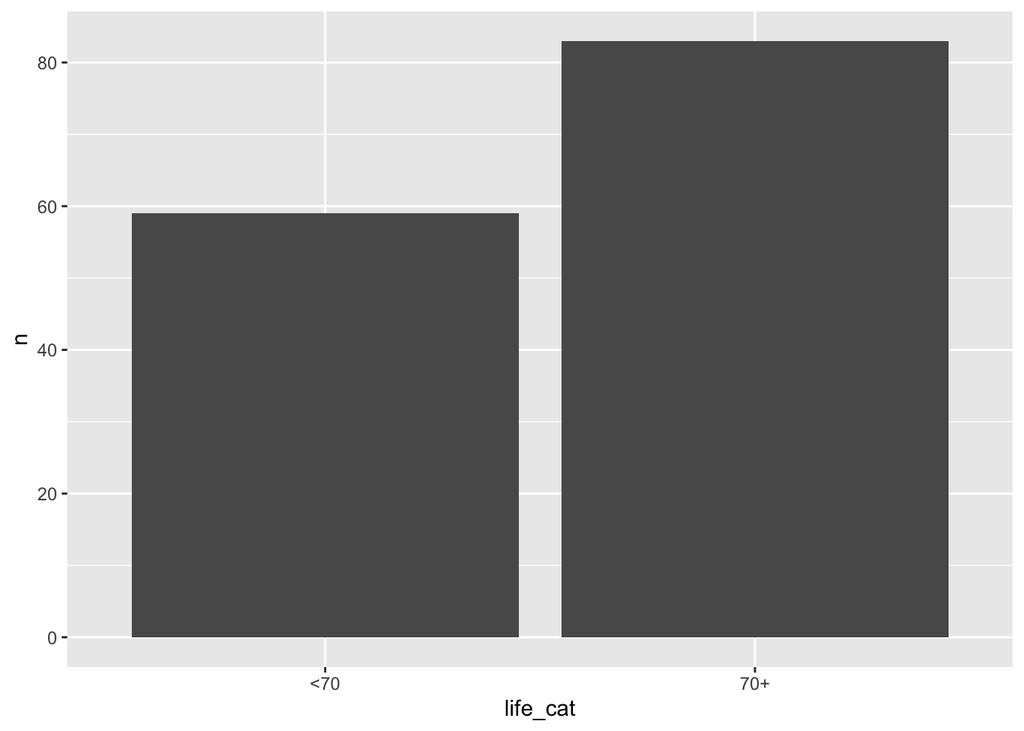

```r
gapminder_2007 %>%
  count(life_cat) %>%
  ggplot() +
  aes(x = life_cat) +
  aes(y = n) +
  geom_col()
```

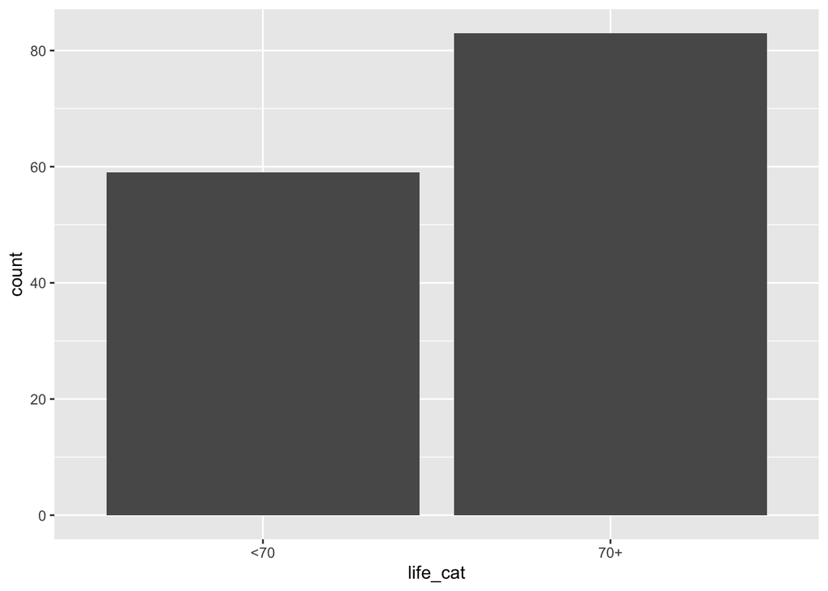

```r
gapminder_2007 %>%
  ggplot() +
  aes(x = life_cat) +
  geom_bar()
```

# On your own

Check out the short description of data, and look at the objects created in the following code chunk `game_goals`, `office_ratings`, `sf_trees`, or `tb_age`.

- [SF trees](https://github.com/rfordatascience/tidytuesday/blob/master/data/2020/2020-01-28/readme.md)
- [nhl](https://github.com/rfordatascience/tidytuesday/blob/master/data/2020/2020-03-03/readme.md)
- [The Office](https://github.com/rfordatascience/tidytuesday/blob/master/data/2020/2020-03-17/readme.md)
- [Brain](https://github.com/rfordatascience/tidytuesday/blob/master/data/2020/2020-03-24/readme.md)

```r
# nhl data
game_goals <- readr::read_csv('https://raw.githubusercontent.com/rfordatascience/tidytuesday/master/data/2020/2020-03-03/game_goals.csv')

# the office series ratings
office_ratings <- readr::read_csv('https://raw.githubusercontent.com/rfordatascience/tidytuesday/master/data/2020/2020-03-17/office_ratings.csv')

sf_trees <- readr::read_csv('https://raw.githubusercontent.com/rfordatascience/tidytuesday/master/data/2020/2020-01-28/sf_trees.csv')

# brain
tbi_age <- readr::read_csv('https://raw.githubusercontent.com/rfordatascience/tidytuesday/master/data/2020/2020-03-24/tbi_age.csv')
```

Build one or two plots with one of these data sets…

```r
# ggplot(data = ?) # uncomment and begin
```